# PolynomialsAndSplines

NareshVemula

September 13, 2016

Loading the necessary packages will work with wage data to implement Polynomial reg, Splines,smoothed Splines and GAM’s

```r
library(ISLR)
attach(Wage)
```

Polynomial Regression and Step Functions Fitting only one variable in regression method with polynomials poly functions helps us to reduce the collinearity by fitting orthogonal polynomials which are linear combinations of all polynomials.

```r
fitPolyWage=lm(wage~poly(age,4),data = Wage)
coef(summary(fitPolyWage))
```

```
##                 Estimate Std. Error    t value     Pr(>|t|)
## (Intercept)    111.70361  0.7287409 153.283015 0.000000e+00
## poly(age, 4)1  447.06785 39.9147851  11.200558 1.484604e-28
## poly(age, 4)2 -478.31581 39.9147851 -11.983424 2.355831e-32
## poly(age, 4)3  125.52169 39.9147851   3.144742 1.678622e-03
## poly(age, 4)4  -77.91118 39.9147851  -1.951938 5.103865e-02
```

```r
fitPolyWage=lm(wage~poly(age,4,raw=F),data = Wage)
coef(fitPolyWage)
```

```
##            (Intercept) poly(age, 4, raw = F)1 poly(age, 4, raw = F)2
##              111.70361              447.06785             -478.31581
## poly(age, 4, raw = F)3 poly(age, 4, raw = F)4
##              125.52169              -77.91118
```

predicting wage using machine generated data computing standard errors to plot

```r
ageRange=range(age)
ageTest=seq(from=ageRange[1],to=ageRange[2])
predictAge=predict(fitPolyWage,newdata = list(age=ageTest),se.fit =T)
seBands=cbind(predictAge$fit+2*predictAge$se.fit,predictAge$fit-2*predictAge$se.fit)
```

plotting the above predictions and SE’s

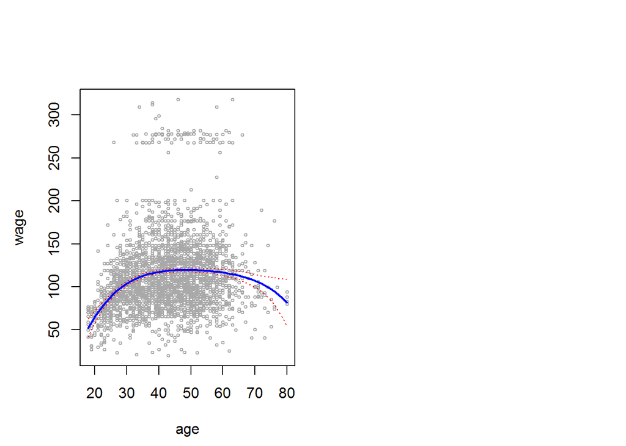

```r
par(mfrow=c(1,2),mar=c(4.5,4.5,1,1),oma=c(0,0,4,0))
plot(age,wage,xlim = ageRange,ylim = range(wage),cex=.5,col="darkgrey")
lines(ageTest,predictAge$fit,lwd=2,col="blue")
matlines(ageTest,seBands,lwd=1,col="red",lty=3)
```

Using Anove to Select the optimum model based on RSS and DF

```r
fitPolyWage1=lm(wage~age,data = Wage)
fitPolyWage2=lm(wage~poly(age,2),data = Wage)
fitPolyWage3=lm(wage~poly(age,3),data = Wage)
fitPolyWage4=lm(wage~poly(age,4),data = Wage)
fitPolyWage5=lm(wage~poly(age,5),data = Wage)

anova(fitPolyWage1,fitPolyWage2,fitPolyWage3,fitPolyWage4,fitPolyWage5)
```

```
## Analysis of Variance Table
##
## Model 1: wage ~ age
## Model 2: wage ~ poly(age, 2)
## Model 3: wage ~ poly(age, 3)
## Model 4: wage ~ poly(age, 4)
## Model 5: wage ~ poly(age, 5)
##   Res.Df     RSS Df Sum of Sq        F    Pr(>F)
## 1   2998 5022216
## 2   2997 4793430  1    228786 143.5931 < 2.2e-16 ***
## 3   2996 4777674  1     15756   9.8888  0.001679 **
## 4   2995 4771604  1      6070   3.8098  0.051046 .
## 5   2994 4770322  1      1283   0.8050  0.369682
## ---
## Signif. codes:  0 '***' 0.001 '**' 0.01 '*' 0.05 '.' 0.1 ' ' 1
```

```r
coef(summary(fitPolyWage5))
```

```
##                 Estimate Std. Error     t value     Pr(>|t|)
## (Intercept)    111.70361  0.7287647 153.2780243 0.000000e+00
## poly(age, 5)1  447.06785 39.9160847  11.2001930 1.491111e-28
## poly(age, 5)2 -478.31581 39.9160847 -11.9830341 2.367734e-32
## poly(age, 5)3  125.52169 39.9160847   3.1446392 1.679213e-03
## poly(age, 5)4  -77.91118 39.9160847  -1.9518743 5.104623e-02
## poly(age, 5)5  -35.81289 39.9160847  -0.8972045 3.696820e-01
```

```r
fitGlm=glm(I(wage>250)~poly(age,4),family  = "binomial",data = Wage)
predictAge=predict(fitGlm,newdata = list(age=ageTest),se.fit = T)
```

computing CI using logistic function

```r
modelFit=exp(predictAge$fit)/(1+exp(predictAge$fit))
seGlm=cbind(predictAge$fit+2*predictAge$se.fit,predictAge$fit-2*predictAge$se.fit)
#changing SE to logistic function scale
seGlm=exp(seGlm)/(1+exp(seGlm))
```

plotting se vs preds

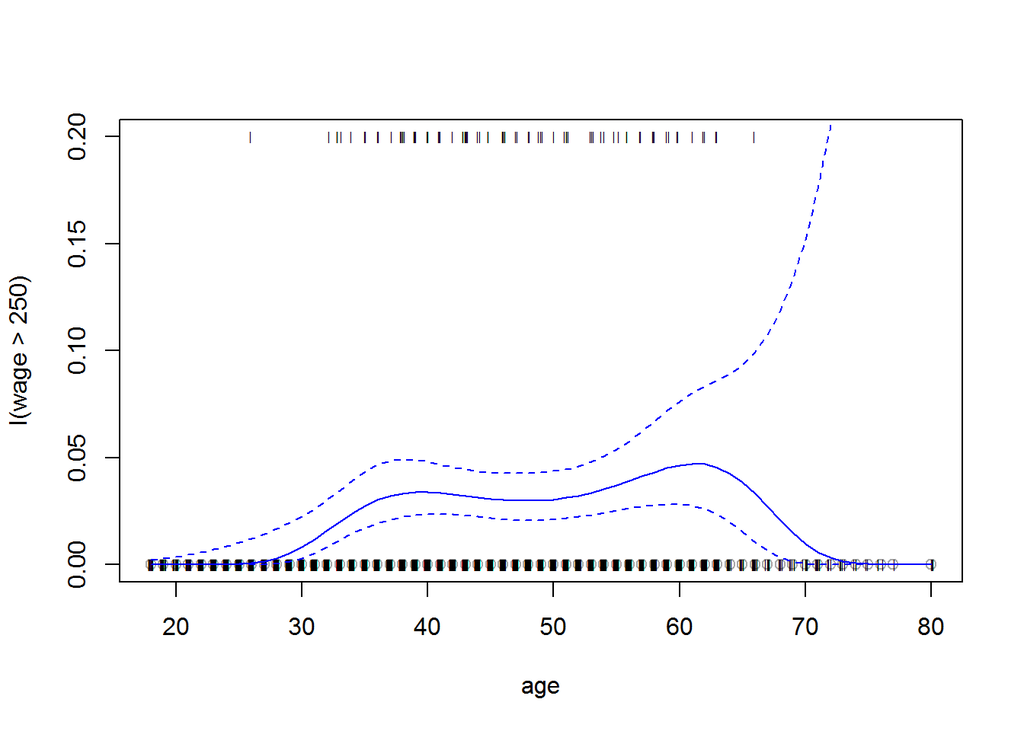

```r
plot(y=I(wage>250),x=age,xlim = ageRange,ylim=c(0,0.2),col="darkgrey")
points(jitter(age),I((wage>250)/5),cex=.5,pch="|")
lines(ageTest,modelFit,col="blue")
matlines(ageTest,seGlm,lwd="1",col="blue",lty=2)
```

fitting step functions using cut in r

```r
table(cut(age,4))
```

```
##
## (17.9,33.5]   (33.5,49]   (49,64.5] (64.5,80.1]
##         750        1399         779          72
```

```r
fitStep=lm(wage~cut(age,4),data = Wage)
summary(fitStep)
```

```
##
## Call:
## lm(formula = wage ~ cut(age, 4), data = Wage)
##
## Residuals:
##     Min      1Q  Median      3Q     Max
## -98.126 -24.803  -6.177  16.493 200.519
##
## Coefficients:
##                        Estimate Std. Error t value Pr(>|t|)
## (Intercept)              94.158      1.476  63.790   <2e-16 ***
## cut(age, 4)(33.5,49]     24.053      1.829  13.148   <2e-16 ***
## cut(age, 4)(49,64.5]     23.665      2.068  11.443   <2e-16 ***
## cut(age, 4)(64.5,80.1]    7.641      4.987   1.532    0.126
## ---
## Signif. codes:  0 '***' 0.001 '**' 0.01 '*' 0.05 '.' 0.1 ' ' 1
##
## Residual standard error: 40.42 on 2996 degrees of freedom
## Multiple R-squared:  0.0625, Adjusted R-squared:  0.06156
## F-statistic: 66.58 on 3 and 2996 DF,  p-value: < 2.2e-16
```

fitting splines

```r
library(splines)
fitLmSplines=lm(wage~bs(age,knots = c(25 ,40 ,60)),data = Wage)
summary(fitLmSplines)
```

```
##
## Call:
## lm(formula = wage ~ bs(age, knots = c(25, 40, 60)), data = Wage)
##
## Residuals:
##     Min      1Q  Median      3Q     Max
## -98.832 -24.537  -5.049  15.209 203.207
##
## Coefficients:
##                                 Estimate Std. Error t value Pr(>|t|)
## (Intercept)                       60.494      9.460   6.394 1.86e-10 ***
## bs(age, knots = c(25, 40, 60))1    3.980     12.538   0.317 0.750899
## bs(age, knots = c(25, 40, 60))2   44.631      9.626   4.636 3.70e-06 ***
## bs(age, knots = c(25, 40, 60))3   62.839     10.755   5.843 5.69e-09 ***
## bs(age, knots = c(25, 40, 60))4   55.991     10.706   5.230 1.81e-07 ***
## bs(age, knots = c(25, 40, 60))5   50.688     14.402   3.520 0.000439 ***
## bs(age, knots = c(25, 40, 60))6   16.606     19.126   0.868 0.385338
## ---
## Signif. codes:  0 '***' 0.001 '**' 0.01 '*' 0.05 '.' 0.1 ' ' 1
##
## Residual standard error: 39.92 on 2993 degrees of freedom
## Multiple R-squared:  0.08642,    Adjusted R-squared:  0.08459
## F-statistic: 47.19 on 6 and 2993 DF,  p-value: < 2.2e-16
```

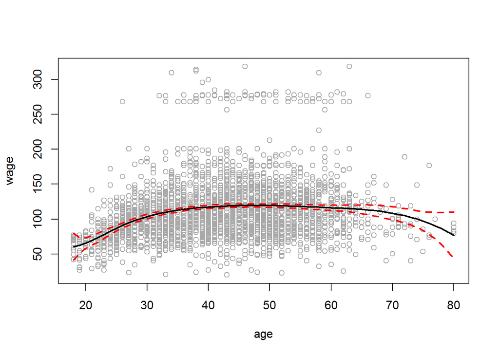

```r
predictWageLs=predict(fitLmSplines,newdata = list(age=ageTest),se.fit = T)
plot(age,wage,col="dark grey")
lines(ageTest,predictWageLs$fit,lwd=2)
lines(ageTest,predictWageLs$fit+2*predictWageLs$se.fit,lty='dashed',col="red",lwd=2)
lines(ageTest,predictWageLs$fit-2*predictWageLs$se.fit,lty='dashed',col="red",lwd=2)
```

dimensions of a cubic spline with three knots is seven (intercept + six basis functions)

```r
dim(bs(age,knots=c(25,20,60)))
```

```
## [1] 3000    6
```

```r
dim(bs(age,df=6))
```

```
## [1] 3000    6
```

```r
attr(bs(age,df=6),"knots")
```

```
##   25%   50%   75%
## 33.75 42.00 51.00
```

fitting natural splines

```r
fitNsSplines=lm(wage~ns(age,knots = c(25 ,40 ,60)),data = Wage)
summary(fitNsSplines)
```

```
##
## Call:
## lm(formula = wage ~ ns(age, knots = c(25, 40, 60)), data = Wage)
##
## Residuals:
##     Min      1Q  Median      3Q     Max
## -98.733 -24.761  -5.187  15.216 204.965
##
## Coefficients:
##                                 Estimate Std. Error t value Pr(>|t|)
## (Intercept)                       54.760      5.138  10.658  < 2e-16 ***
## ns(age, knots = c(25, 40, 60))1   67.402      5.013  13.444  < 2e-16 ***
## ns(age, knots = c(25, 40, 60))2   51.383      5.712   8.996  < 2e-16 ***
## ns(age, knots = c(25, 40, 60))3   88.566     12.016   7.371 2.18e-13 ***
## ns(age, knots = c(25, 40, 60))4   10.637      9.833   1.082    0.279
## ---
## Signif. codes:  0 '***' 0.001 '**' 0.01 '*' 0.05 '.' 0.1 ' ' 1
##
## Residual standard error: 39.92 on 2995 degrees of freedom
## Multiple R-squared:  0.08588,    Adjusted R-squared:  0.08466
## F-statistic: 70.34 on 4 and 2995 DF,  p-value: < 2.2e-16
```

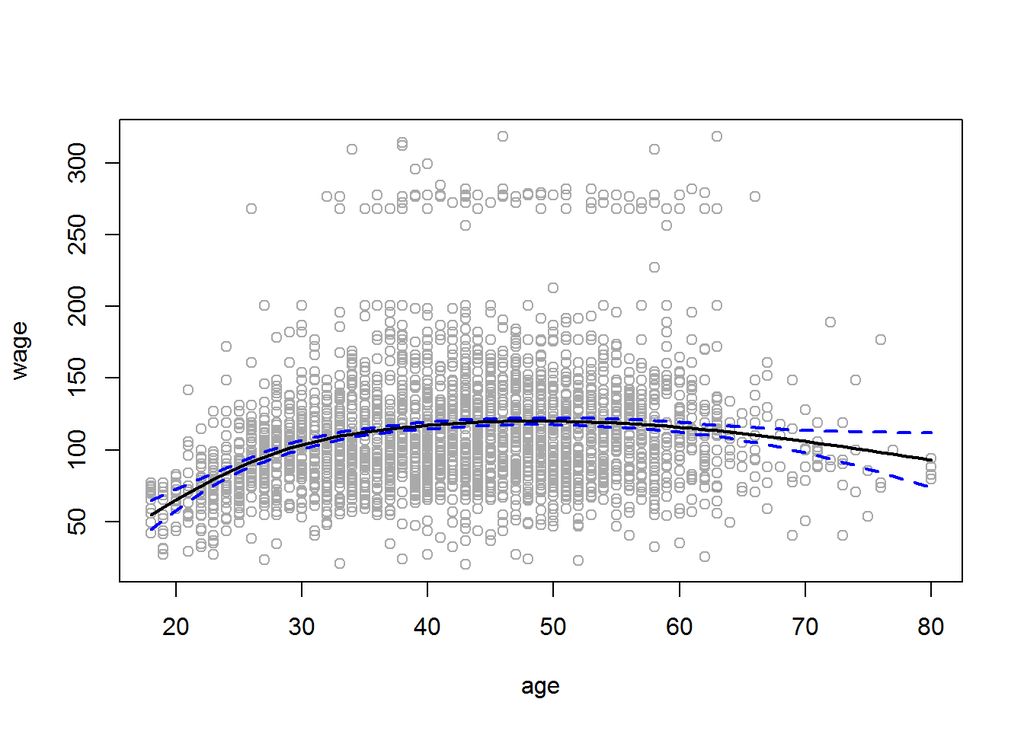

```r
predictWage=predict(fitNsSplines,newdata = list(age=ageTest),se.fit = T)
plot(age,wage,col="dark grey")
lines(ageTest,predictWage$fit,lwd=2)
lines(ageTest,predictWage$fit+2*predictWage$se.fit,lty='dashed',col="blue",lwd=2)
lines(ageTest,predictWage$fit-2*predictWage$se.fit,lty='dashed',col="blue",lwd=2)
```

working with smoothing splines

```r
plot(age,wage,xlim = ageRange,cex=.5,col="darkgrey")
title("smoothing splines")
fitSmooth=smooth.spline(age,wage,df=16)
fitSmoothCV=smooth.spline(age,wage,cv = T)
fitSmoothCV
```

```
## Call:
## smooth.spline(x = age, y = wage, cv = T)
##
## Smoothing Parameter  spar= 0.6988943  lambda= 0.02792303 (12 iterations)
## Equivalent Degrees of Freedom (Df): 6.794596
## Penalized Criterion: 75215.9
## PRESS: 1593.383
```

```r
fitSmoothCV$df
```

```
## [1] 6.794596
```

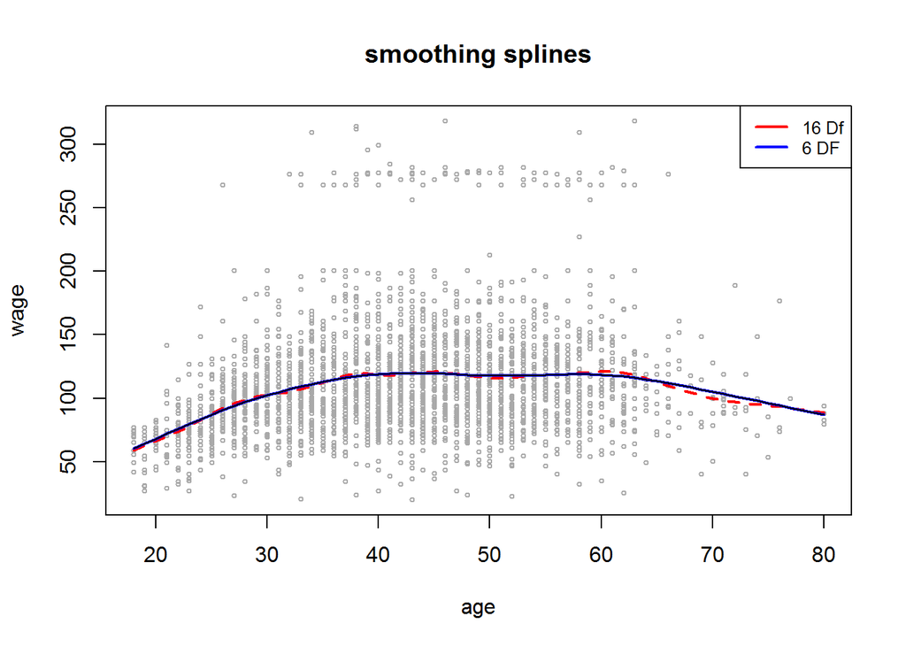

```r
lines(fitSmooth,col="red",lwd=2,lty="dashed")
lines(fitSmoothCV,col="blue",lwd=2)
legend("topright",legend = c("16 Df","6 DF"),col=c("red","blue"),lty=1,lwd=2,cex=.8)
predictSmooth=predict(fitSmoothCV,newdata=list(age=ageTest),se.fit=T)
lines(predictSmooth$x,predictSmooth$y)
```

using local regression we can also use locfit library for local regression

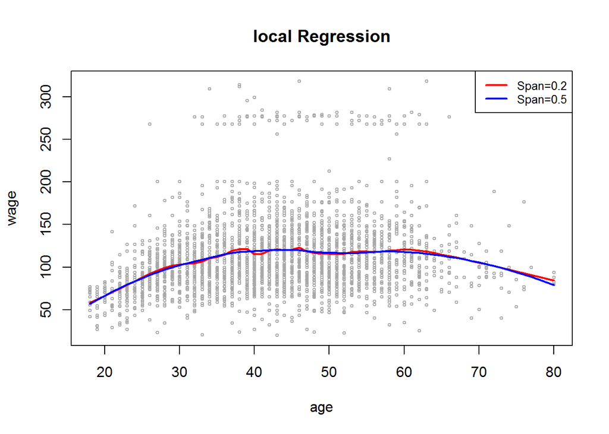

```r
plot(age,wage,cex=.5,xlim = ageRange,col="darkgrey")
title("local Regression")
fitLocalReg=loess(wage~age,span = 0.2,data = Wage)
fitLocalReg50=loess(wage~age,span = 0.5,data = Wage)
predictLoess=predict(fitLocalReg,newdata =data.frame(age=ageTest),se=T)
predictLoess50=predict(fitLocalReg50,newdata =data.frame(age=ageTest),se=T)
lines(ageTest,predictLoess$fit,lwd=2,col="red")
lines(ageTest,predictLoess50$fit,lwd=2,col="blue")
legend("topright",legend = c("Span=0.2","Span=0.5"),col = c("red","blue"),cex=.8,lty=1,lwd=2)
```

Hooo, Welcome to GAM’s Naresh

```r
gam1=lm(wage~ns(year,4)+ns(age,5)+education,data = Wage)
```

fitting gam’s using gam library

```r
library(gam)
```

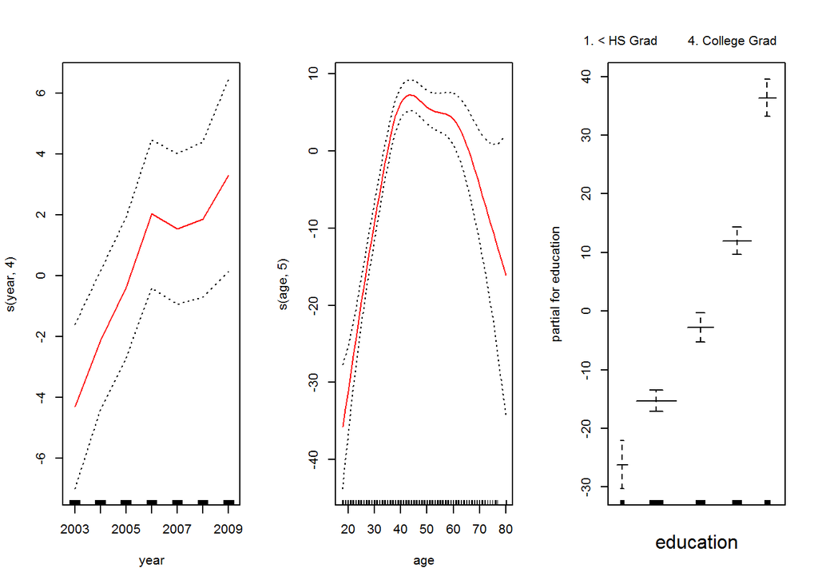

```r
gamWage3=gam(wage~s(year,4)+s(age,5)+education,data = Wage)
par(mfrow=c(1,3))
plot.gam(gamWage3,se = T,col="red")
```

it is evident that year is linear in nature from above plots test with anova

```r
gamWage1=gam(wage~s(age,5)+education,data = Wage)
gamWage2=gam(wage~year+s(age,5)+education,data = Wage)
anova(gamWage1,gamWage2,gamWage3,test = "F")
```

```
## Analysis of Deviance Table
##
## Model 1: wage ~ s(age, 5) + education
## Model 2: wage ~ year + s(age, 5) + education
## Model 3: wage ~ s(year, 4) + s(age, 5) + education
##   Resid. Df Resid. Dev Df Deviance       F    Pr(>F)
## 1      2990    3711731
## 2      2989    3693842  1  17889.2 14.4771 0.0001447 ***
## 3      2986    3689770  3   4071.1  1.0982 0.3485661
## ---
## Signif. codes:  0 '***' 0.001 '**' 0.01 '*' 0.05 '.' 0.1 ' ' 1
```

```r
summary(gamWage3)
```

```
##
## Call: gam(formula = wage ~ s(year, 4) + s(age, 5) + education, data = Wage)
## Deviance Residuals:
##     Min      1Q  Median      3Q     Max
## -119.43  -19.70   -3.33   14.17  213.48
##
## (Dispersion Parameter for gaussian family taken to be 1235.69)
##
##     Null Deviance: 5222086 on 2999 degrees of freedom
## Residual Deviance: 3689770 on 2986 degrees of freedom
## AIC: 29887.75
##
## Number of Local Scoring Iterations: 2
##
## Anova for Parametric Effects
##              Df  Sum Sq Mean Sq F value    Pr(>F)
## s(year, 4)    1   27162   27162  21.981 2.877e-06 ***
## s(age, 5)     1  195338  195338 158.081 < 2.2e-16 ***
## education     4 1069726  267432 216.423 < 2.2e-16 ***
## Residuals  2986 3689770    1236
## ---
## Signif. codes:  0 '***' 0.001 '**' 0.01 '*' 0.05 '.' 0.1 ' ' 1
##
## Anova for Nonparametric Effects
##             Npar Df Npar F  Pr(F)
## (Intercept)
## s(year, 4)        3  1.086 0.3537
## s(age, 5)         4 32.380 <2e-16 ***
## education
## ---
## Signif. codes:  0 '***' 0.001 '**' 0.01 '*' 0.05 '.' 0.1 ' ' 1
```

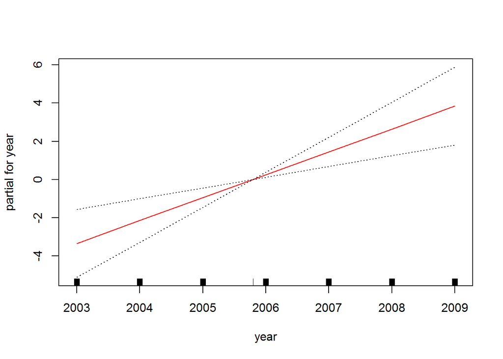

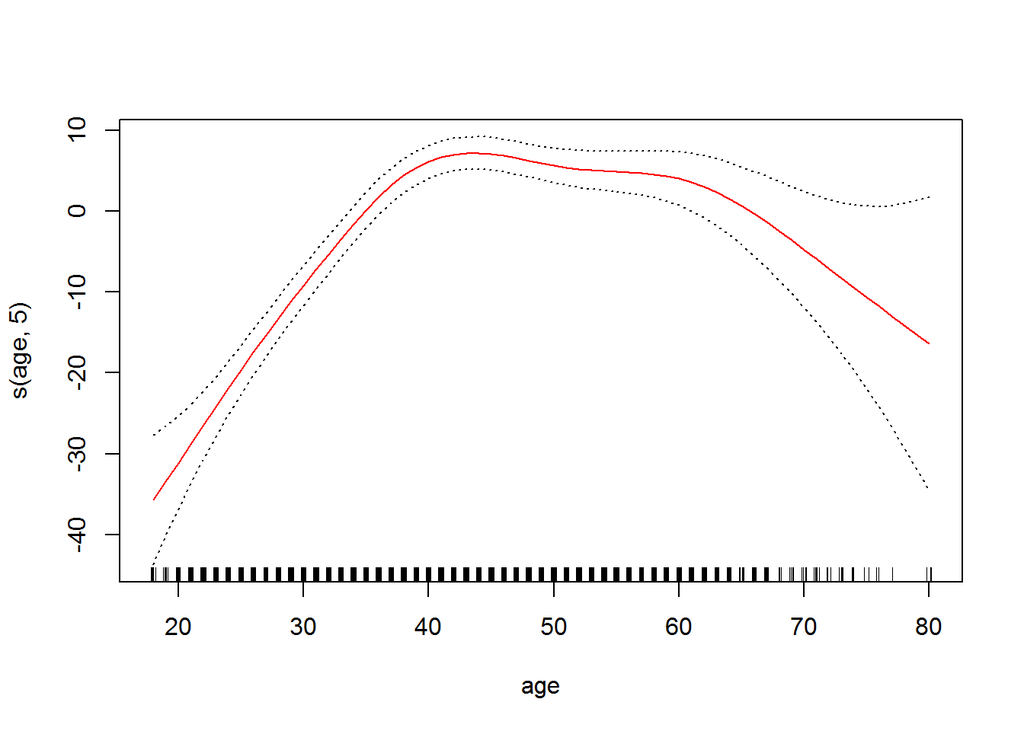

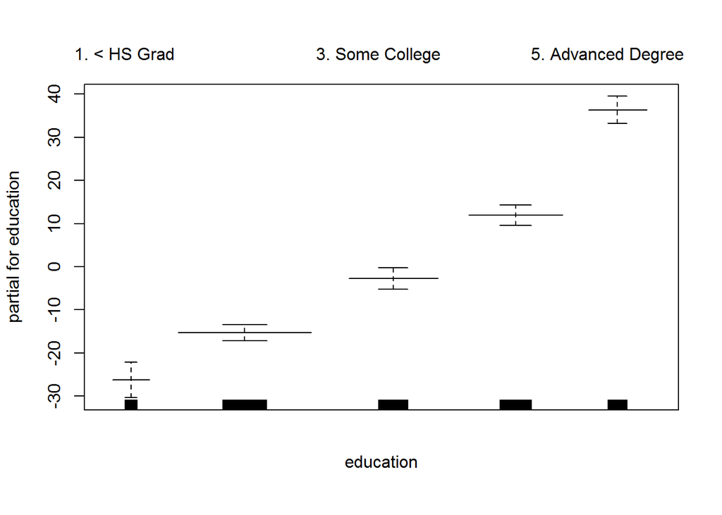

```r
plot.gam(gamWage2,se=T,col="red")
```

fitting local regression in gam’s

```r
gamLocal=gam(wage~lo(year,age,span = 0.3)+education,data = Wage)
summary(gamLocal)
```

```
##
## Call: gam(formula = wage ~ lo(year, age, span = 0.3) + education, data = Wage)
## Deviance Residuals:
##      Min       1Q   Median       3Q      Max
## -120.131  -19.846   -3.272   14.332  212.452
##
## (Dispersion Parameter for gaussian family taken to be 1232.989)
##
##     Null Deviance: 5222086 on 2999 degrees of freedom
## Residual Deviance: 3676128 on 2981.478 degrees of freedom
## AIC: 29885.68
##
## Number of Local Scoring Iterations: 2
##
## Anova for Parametric Effects
##                               Df  Sum Sq Mean Sq F value    Pr(>F)
## lo(year, age, span = 0.3)    2.0  217479  108740  88.192 < 2.2e-16 ***
## education                    4.0 1065792  266448 216.099 < 2.2e-16 ***
## Residuals                 2981.5 3676128    1233
## ---
## Signif. codes:  0 '***' 0.001 '**' 0.01 '*' 0.05 '.' 0.1 ' ' 1
##
## Anova for Nonparametric Effects
##                           Npar Df Npar F     Pr(F)
## (Intercept)
## lo(year, age, span = 0.3)    11.5 12.541 < 2.2e-16 ***
## education
## ---
## Signif. codes:  0 '***' 0.001 '**' 0.01 '*' 0.05 '.' 0.1 ' ' 1
```

```r
library(akima)
```

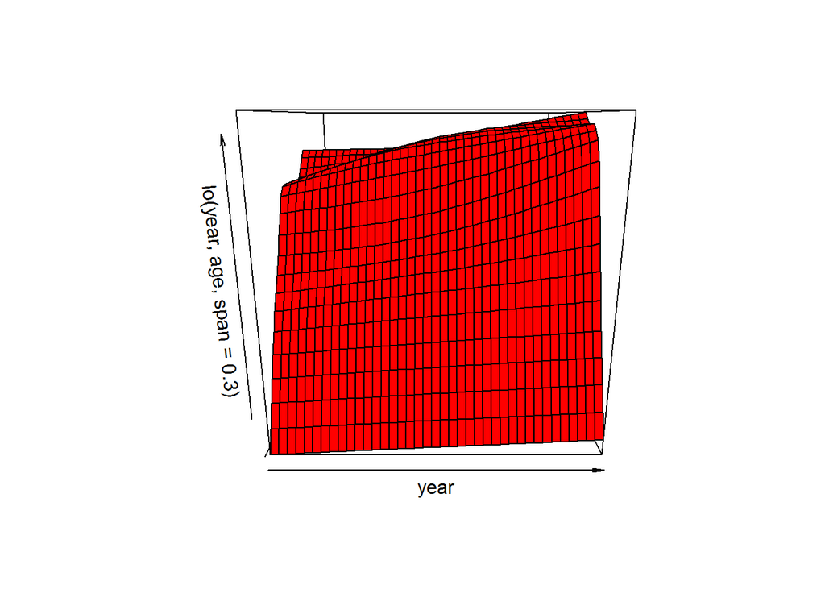

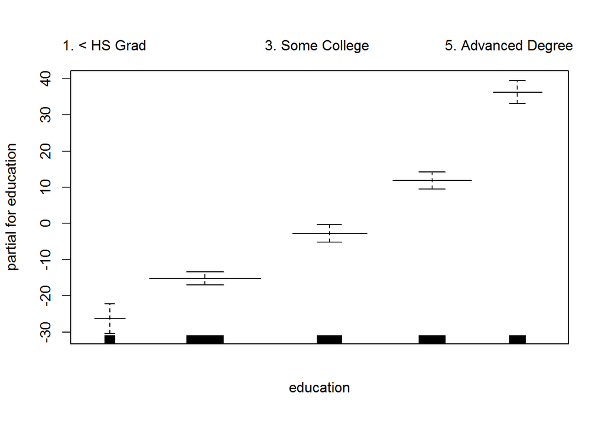

```r
plot.gam(gamLocal,se=T,col="red")
```

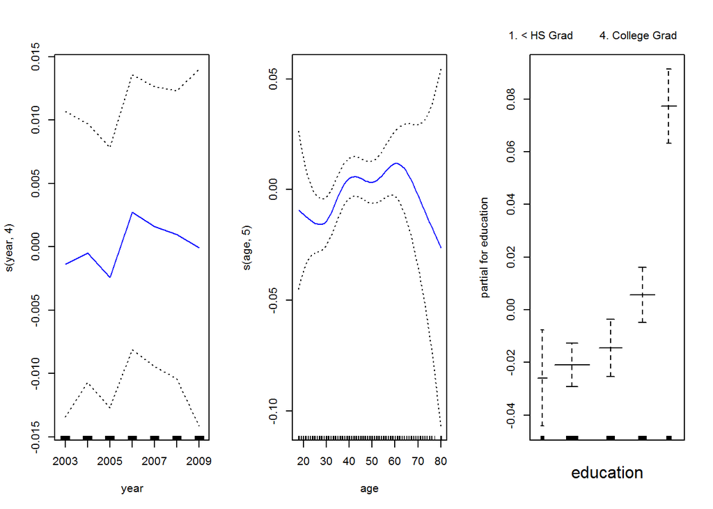

```r
gamLogitWage3=gam(I(wage>250)~s(year,4)+s(age,5)+education,data = Wage)
par(mfrow=c(1,3))
plot.gam(gamLogitWage3,se=T,col="blue")
```

```r
table(education,I(wage>250))
```

```
##
## education            FALSE TRUE
##   1. < HS Grad         268    0
##   2. HS Grad           966    5
##   3. Some College      643    7
##   4. College Grad      663   22
##   5. Advanced Degree   381   45
```

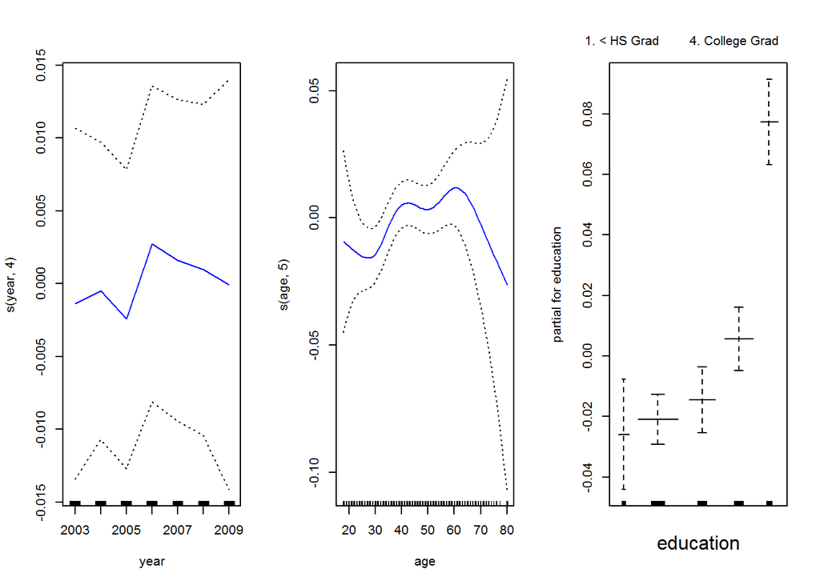

```r
gamLogitWage3=gam(I(wage>250)~s(year,4)+s(age,5)+education,data = Wage,subset = (education!="< HS Grad"))
par(mfrow=c(1,3))
plot.gam(gamLogitWage3,se=T,col="blue")
```